# Schritt 1: Laden des 'hsdar'-Pakets

Das 'caret'-Paket wird im Hintergrund mitgeladen. Für spätere Funktionen brauchen wir noch das Paket 'randomForest'.

```r
library(hsdar)
library(randomForest)
```

# Schritt 2: Einlesen der Hyperspektraldaten und Vorprozessierung

Dieser Schritt ist abhängig vom Projekt. Wir wollen hier den in hsdar vorhandenen Datensatz zur Schätzung von Chlorophyllgehalt nutzen und die Spektren mit einem Savitzky-Golay Filter entrauschen:

```r
data('spectral_data')
spectral_data <- noiseFiltering(spectral_data, method = "sgolay", p = 15)
```

Wir 'schneiden' die Speclib auf den spektralen Bereich zu, in dem Chlorophyll einen Effekt auf die Reflektanz hat

```r
spectral_data <- spectral_data[, wavelength(spectral_data) >= 310 & wavelength(spectral_data) <= 1000]
```

Die summary der Speclib sieht nun folgendermaßen aus:

```r
spectral_data
```

```
Summary of Speclib


History of usage
---------------------
(1)   Reflectance = mean applied to matrix spectra by attribute 'site'
(2)   Filtered with Savitzky-Golay filter
(3)   Subsetting speclib (spectral dimension)


Summary of spectra
---------------------
Total number of spectra : 45
Number of bands : 691
Width of bands : 1
Spectral range of data : 310 - 1000 nm


Speclib contains SI
---------------------
    Variables Classes
1        year integer
2      season  factor
3        site  factor
4 chlorophyll numeric
```

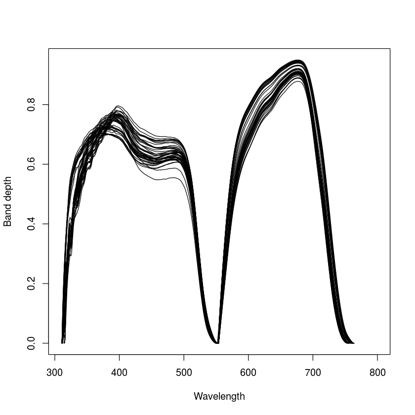

```r
spec_bd <- transformSpeclib(spectral_data, method = "sh", out = "bd")
featureSpace <- specfeat(spec_bd, c(460, 670))
featureSpace <- feature_properties(featureSpace)
plot(featureSpace, xlim = c(310,800))
```

# Schritt 3: Auswahl der Prädiktoren und training des Random forest Modells

Hierzu definieren wir zunächst die "Response"-Variable (abhängige Variable, die geschätzt werden soll). Als Prädiktoren werden alle Bänder (in diesem Fall band depth Werte statt der Reflektanzen) per Voreinstellung von hsdar verwendet. Zusätzlich kann man weitere Prädiktoren verwenden, die aus dem SI kommen. In unserem Beispiel sind das die Eigenschaften der beiden Features:

```r
featureSpace <- setResponse(featureSpace, "chlorophyll")
names(SI(featureSpace))
```

1. 'year'

2. 'season'

3. 'site'

4. 'chlorophyll'

5. 'f460_area'

6. 'f670_area'

7. 'f460_maxwl'

8. 'f670_maxwl'

9. 'f460_lo_wlhm'

10. 'f460_up_wlhm'

11. 'f460_width_wlhm'

12. 'f460gauss_lo_wlhm'

13. 'f460gauss_up_wlhm'

14. 'f670_lo_wlhm'

15. 'f670_up_wlhm'

16. 'f670_width_wlhm'

17. 'f670gauss_lo_wlhm'

18. 'f670gauss_up_wlhm'

19. 'f460_max'

20. 'f670_max'

Somit wollen wir alle Spalten ab der 5. nutzen:

```r
featureSpace <- setPredictor(featureSpace, names(SI(featureSpace))[5:ncol(SI(featureSpace))])
```

Nun sieht die Summary der Speclib so aus:

```r
featureSpace
```

```
Summary of Specfeat


History of usage
---------------------
(1)   Reflectance = mean applied to matrix spectra by attribute 'site'
(2)   Filtered with Savitzky-Golay filter
(3)   Subsetting speclib (spectral dimension)
(4)   Reflectance = transform (sh), bd
(5)   Extract feature(s)
(6)   Properties of features calculated
(7)   Response variable(s) set to "chlorophyll"
(8)   Predictor variable(s) set to "f460_area", "f670_area", "f460_maxwl", "f670_maxwl", "f460_lo_wlhm", "f460_up_wlhm", "f460_width_wlhm", "f460gauss_lo_wlhm", "f460gauss_up_wlhm", "f670_lo_wlhm", "f670_up_wlhm", "f670_width_wlhm", "f670gauss_lo_wlhm", "f670gauss_up_wlhm", "f460_max", "f670_max"


Summary of spectra
---------------------
Total number of spectra : 45
Number of bands : 691
Width of bands : 1
Spectral range of data : 310 - 1000 nm


Speclib contains SI
---------------------
           Variables Classes Predictors Response
1               year integer
2             season  factor
3               site  factor
4        chlorophyll numeric                   *
5          f460_area numeric          *
6          f670_area numeric          *
7         f460_maxwl numeric          *
8         f670_maxwl numeric          *
9       f460_lo_wlhm numeric          *
10      f460_up_wlhm numeric          *
11   f460_width_wlhm numeric          *
12 f460gauss_lo_wlhm numeric          *
13 f460gauss_up_wlhm numeric          *
14      f670_lo_wlhm numeric          *
15      f670_up_wlhm numeric          *
16   f670_width_wlhm numeric          *
17 f670gauss_lo_wlhm numeric          *
18 f670gauss_up_wlhm numeric          *
19          f460_max numeric          *
20          f670_max numeric          *
```

Nun kommt ein kritischer Schritt: Wir müssen definieren, wie wir das Modell trainieren und validieren wollen. Unser Datensatz umfasst 'nur' 45 Spektren, so dass es nicht sinnvoll ist, den Datensatz komplett zu spalten in einen Teildatensatz für Training und einen zum Validieren. Stattdessen verwenden wir eine sog. "repeated cross-validation", bei der wir den Datensatz zunächst in 10 Teildatensätze spalten (`number = 10`). Es werden dann immer 9 Teildatensätze zum Trainieren des Modells und einer zum Validieren verwendet. Das läuft dann schrittweise durch, so dass am Ende jeder Teildatensatz 1 Mal zum Validieren verwendet wurde. Nun ist die Aufteilung des Datensatzes in Teildatensätze natürlich zufallsgesteuert. Daher wiederholen wir den ganzen Prozess insgesamt 5 Mal (`repeats = 5`).

```r
ctrl <- trainControl(method = "repeatedcv", number = 10, repeats = 5, savePredictions = "final")
```

Nun können wir das Modell trainieren (dauert u.U. ziemlich lange):

```r
rfe_trained <- train(featureSpace, trControl = ctrl, method = "rf")
```

```r
rfe_trained
```

```
Random Forest

 45 samples
452 predictors

No pre-processing
Resampling: Cross-Validated (10 fold, repeated 5 times)
Summary of sample sizes: 41, 39, 40, 40, 41, 40, ...
Resampling results across tuning parameters:

  mtry  RMSE      Rsquared   MAE
    2   3.685541  0.8553192  3.060614
  227   3.454617  0.8580643  2.918191
  452   3.376395  0.8622127  2.853584

RMSE was used to select the optimal model using the smallest value.
The final value used for the model was mtry = 452.
```

Man sieht nun, dass das finale Modell mit einem mtry von 452 trainiert wurde, da hier der Fehler am niedrigsten ist (RMSE).

# Evaluierung der Modellgüte

Um die Genauigkeit des Modells zu bestimmen, müssen wir die mit unabhängigen Daten geschätzten Werte aus dem Modell extrahieren (10. Teildatensatz). Anschließend können wir das *R²* und den *RMSE* (root mean square error) berechnen.

```r
estimates <- tapply(rfe_trained$pred$pred[order(rfe_trained$pred$rowIndex)],
                    INDEX = rfe_trained$pred$rowIndex[order(rfe_trained$pred$rowIndex)], mean)
measured <- SI(featureSpace)$chlorophyll
r_squared <- round(summary(lm(estimates ~ measured))$r.squared, 2)
rmse_val <- round(sqrt(mean((estimates - measured)^2, na.rm = TRUE)),2)
cat(paste("r_squared =", r_squared,"\n"))
cat(paste("RMSE =", rmse_val,"\n"))
```

```
r_squared = 0.82
RMSE = 3.44
```

Die Schätzgenauigkeit können wir auch visuell überprüfen, indem wir die geschätzen gegen die gemessenen Chlorophyllwerte plotten:

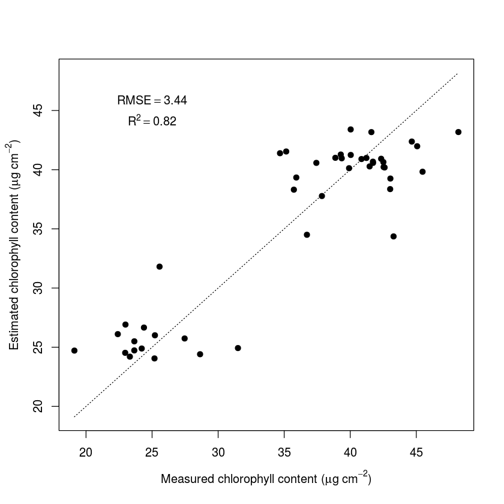

```r
lim <- range(c(range(estimates), range(measured)))
plot(estimates ~ measured, ylim = lim, xlim = lim, pch  = 19,
     xlab = expression(paste("Measured chlorophyll content (",
                             mu, plain(g)~plain(cm)^{-2}, ")",
                             sep = "")),
     ylab = "")
lines(lim, lim, lty = "dotted")
text(25, 45, substitute(atop(RMSE == x, R^2 == y),
                         list(x = rmse_val,
                              y = r_squared)))
title(ylab = expression(paste("Estimated chlorophyll content (",
                              mu, plain(g)~plain(cm)^{-2}, ")",
                              sep = "")),
      line = 2.5)
```

Nun kann man sich ansehen, welche Variablen für die Schätzung des Chlorophyllgehalts wichtig sind. Dies wird berechnet aus der Anteil an Bäumen, in denen die jeweilige Variable verwendet wurde.

```r
importance <- importance(rfe_trained$finalModel)
importance <- importance[order(importance[,1], decreasing = TRUE),]
print(importance[1:10])
```

```
            V_550 f460gauss_lo_wlhm        f460_maxwl             V_549
        237.25893         212.28290         143.43239         140.12934
            V_316             V_317             V_315             V_545
        133.63701         129.17326         115.92791         107.34997
            V_548             V_547
         66.63286          59.50071
```